# 11 - MACHINE LEARNING WITH CARET

Joseph Rickert

September 28, 2015

caret (short for Classification and REgression Training) is the most feature rich package for doing machine learning in R. It provides functions to streamline the entire process and includes tools for:  
* data splitting  
* pre-processing  
* feature selection  
* model tuning using resampling  
* variable importance estimation

This script explores caret’s capabilities using a cell segmentation data set that is included in the package. The data is described in the paper: Hill et al “Impact of image segmentation on high-content screening data quality for SK-BR-3 cells” BMC fioinformatics (2007) vol 8 (1) pp. 340

The analysis presented here is based on examples presented by Max Kuhn, caret’s author, at Use-R 2012.

### Background

“Well-segmented”" cells are cells for which location and size may be accurrately detremined through optical measurements. Cells that are not Well-segmented (WS) are said to be “Poorly-segmented”" (PS). Given a set of optical measurements can we predict which cells will be PS? This is a classic classification problem

### Packages Required

```r
library(caret)
```

```r
library(corrplot)           # plot correlations
library(doParallel)     # parallel processing
library(dplyr)         # Used by caret
library(gbm)                  # Boosting algorithms
library(kernlab)      # support vector machine
library(partykit)           # Plotting trees
library(pROC)                 # plot the ROC curve
library(rpart)              # CART algorithm for decision trees
```

### Get the Data

Load the data and construct indices to divied it into training and test data sets.

```r
data(segmentationData)      # Load the segmentation data set
dim(segmentationData)
```

```
## [1] 2019   61
```

```r
#head(segmentationData,2)
#
trainIndex <- createDataPartition(segmentationData$Case,p=.5,list=FALSE)
trainData <- segmentationData[trainIndex,]
dim(trainData)
```

```
## [1] 1010   61
```

```r
#
testData  <- segmentationData[-trainIndex,]
dim(testData)
```

```
## [1] 1009   61
```

```r
#
trainX <-trainData[,4:61]        # Pull out the variables for training
sapply(trainX,summary) # Look at a summary of the training data
```

```
##          AngleCh1 AreaCh1 AvgIntenCh1 AvgIntenCh2 AvgIntenCh3 AvgIntenCh4
## Min.      0.03184   150.0       15.17        1.00        0.12      0.6316
## 1st Qu.  52.52000   192.0       35.52       52.21       33.25     42.0600
## Median   90.57000   257.5       61.79      174.70       68.89     91.8400
## Mean     90.23000   325.0      126.60      193.90       97.56    144.2000
## 3rd Qu. 126.60000   367.0      141.20      287.50      125.90    199.6000
## Max.    179.90000  1975.0     1419.00      989.50      725.20    886.8000
##         ConvexHullAreaRatioCh1 ConvexHullPerimRatioCh1 DiffIntenDensityCh1
## Min.                     1.006                  0.5106               25.76
## 1st Qu.                  1.066                  0.8592               43.32
## Median                   1.150                  0.9143               55.45
## Mean                     1.204                  0.8966               72.85
## 3rd Qu.                  1.279                  0.9557               80.13
## Max.                     2.793                  0.9965              396.60
##         DiffIntenDensityCh3 DiffIntenDensityCh4 EntropyIntenCh1
## Min.                  1.501               2.605           4.834
## 1st Qu.              28.940              33.010           6.028
## Median               55.020              60.960           6.574
## Mean                 74.700              90.090           6.577
## 3rd Qu.              96.460             122.300           7.024
## Max.                470.700             531.300           9.476
##         EntropyIntenCh3 EntropyIntenCh4 EqCircDiamCh1 EqEllipseLWRCh1
## Min.             0.2167           0.512         13.86           1.009
## 1st Qu.          4.5660           4.729         15.67           1.418
## Median           5.8400           5.767         18.14           1.839
## Mean             5.4460           5.543         19.59           2.112
## 3rd Qu.          6.5820           6.694         21.64           2.435
## Max.             7.9970           8.273         50.16          10.140
##         EqEllipseOblateVolCh1 EqEllipseProlateVolCh1 EqSphereAreaCh1
## Min.                    146.5                  64.01           603.8
## 1st Qu.                 278.5                 146.70           771.5
## Median                  437.2                 225.60          1034.0
## Mean                    730.7                 371.70          1302.0
## 3rd Qu.                 812.8                 403.10          1472.0
## Max.                  11690.0                5155.00          7903.0
##         EqSphereVolCh1 FiberAlign2Ch3 FiberAlign2Ch4 FiberLengthCh1
## Min.              1395          1.000          1.000          11.87
## 1st Qu.           2015          1.262          1.238          20.88
## Median            3124          1.462          1.447          29.18
## Mean              5047          1.448          1.423          34.77
```

[output cut: 50 more lines]

```
## Max.               50.000        741400        363300        228400
##         TotalIntenCh4 VarIntenCh1 VarIntenCh3 VarIntenCh4 WidthCh1
## Min.               96       11.47      0.8693       2.519    6.393
## 1st Qu.         10240       25.13     37.4600      49.130   13.770
## Median          25480       42.18     70.2700      89.310   16.230
## Mean            42430       72.85    102.3000     124.200   17.710
## 3rd Qu.         57380       83.56    123.0000     166.600   20.170
## Max.           519600      575.80    757.0000     933.500   51.740
##         XCentroid YCentroid
## Min.         11.0       8.0
## 1st Qu.     139.5      85.0
## Median      257.5     158.0
## Mean        256.4     173.5
## 3rd Qu.     376.0     247.0
## Max.        501.0     480.0
```

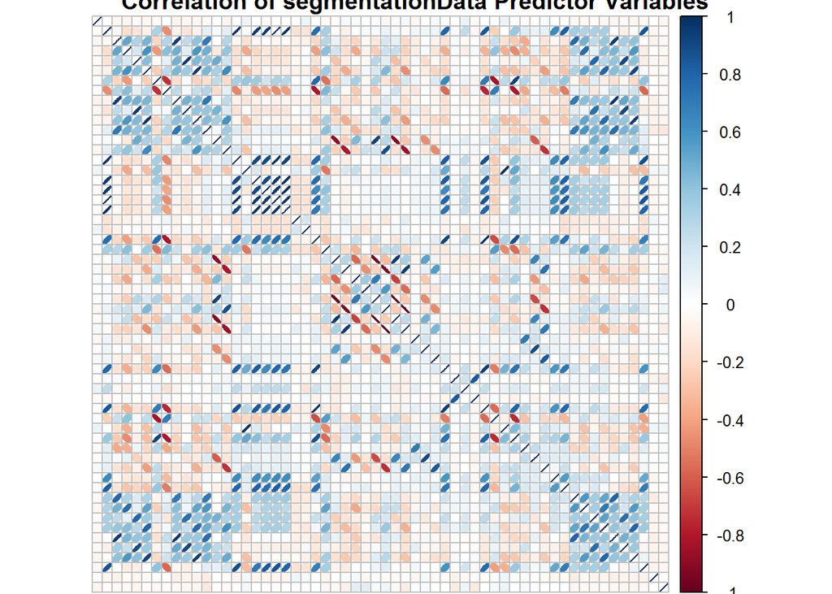

```r
corrplot(cor(trainX),
         method="ellipse",
         tl.pos="n",
         title="Correlation of segmentationData Predictor Variables")
```

## BUILD A DECISION TREE MODEL We build a basic tree model with rpart.

```r
tree.mod <- rpart(Class ~ .,data=trainData[,-c(1,2)],control=rpart.control(maxdepth=2))
tree.mod
```

```
## n= 1010
##
## node), split, n, loss, yval, (yprob)
##       * denotes terminal node
##
## 1) root 1010 368 PS (0.63564356 0.36435644)
##   2) TotalIntenCh2< 46541.5 469  39 PS (0.91684435 0.08315565) *
##   3) TotalIntenCh2>=46541.5 541 212 WS (0.39186691 0.60813309)
##     6) FiberWidthCh1< 11.35165 240  97 PS (0.59583333 0.40416667) *
##     7) FiberWidthCh1>=11.35165 301  69 WS (0.22923588 0.77076412) *
```

Visualize the tree

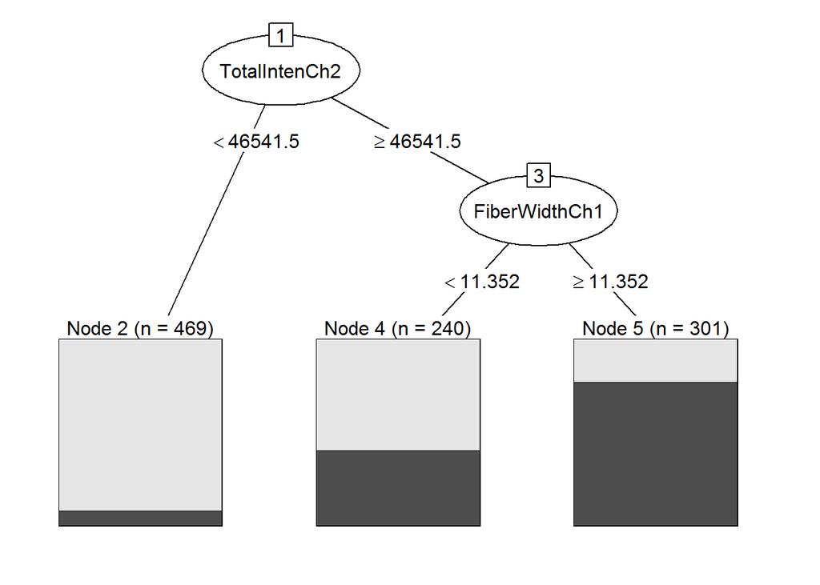

```r
tree.mod.p <- as.party(tree.mod)    # make the tree.mod object into a party object
plot(tree.mod.p)
```

## GENERALIZED BOOSTED REGRGRESSION MODEL

We build a gbm model. Note that the gbm function does not allow factor “class” variables

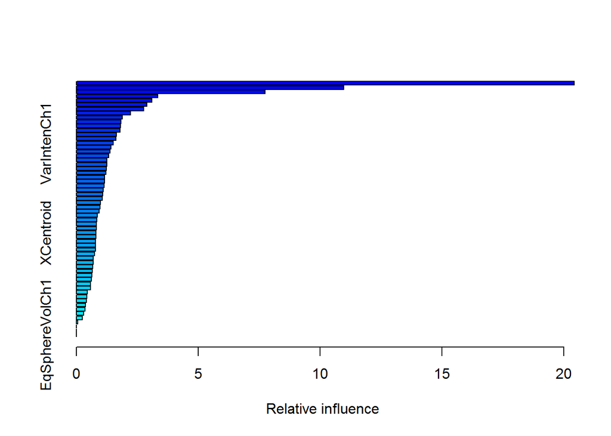

```
##                                             var     rel.inf
## TotalIntenCh2                     TotalIntenCh2 20.42597566
## FiberWidthCh1                     FiberWidthCh1 10.97742497
## Cell                                       Cell  7.74573549
## ShapeP2ACh1                         ShapeP2ACh1  3.34616683
## TotalIntenCh1                     TotalIntenCh1  3.09207721
## AvgIntenCh2                         AvgIntenCh2  2.89472111
## AvgIntenCh1                         AvgIntenCh1  2.76603970
## KurtIntenCh1                       KurtIntenCh1  2.23106919
## ConvexHullPerimRatioCh1 ConvexHullPerimRatioCh1  1.89166794
## IntenCoocContrastCh4       IntenCoocContrastCh4  1.83822618
## EntropyIntenCh1                 EntropyIntenCh1  1.81716609
## IntenCoocContrastCh3       IntenCoocContrastCh3  1.79104667
## DiffIntenDensityCh3         DiffIntenDensityCh3  1.65134369
## ConvexHullAreaRatioCh1   ConvexHullAreaRatioCh1  1.61664561
## VarIntenCh1                         VarIntenCh1  1.50604446
## TotalIntenCh3                     TotalIntenCh3  1.42035298
## FiberAlign2Ch4                   FiberAlign2Ch4  1.38493726
## ShapeBFRCh1                         ShapeBFRCh1  1.33510433
## DiffIntenDensityCh4         DiffIntenDensityCh4  1.24820023
## EqEllipseProlateVolCh1   EqEllipseProlateVolCh1  1.24518759
## VarIntenCh4                         VarIntenCh4  1.23145888
## TotalIntenCh4                     TotalIntenCh4  1.21090865
## SkewIntenCh3                       SkewIntenCh3  1.16521916
## NeighborAvgDistCh1           NeighborAvgDistCh1  1.15785935
## SkewIntenCh1                       SkewIntenCh1  1.13561738
## IntenCoocEntropyCh3         IntenCoocEntropyCh3  1.10869648
## SkewIntenCh4                       SkewIntenCh4  1.08151376
## AngleCh1                               AngleCh1  1.05694223
## NeighborMinDistCh1           NeighborMinDistCh1  0.98719610
## KurtIntenCh4                       KurtIntenCh4  0.96981158
## YCentroid                             YCentroid  0.92714384
## FiberAlign2Ch3                   FiberAlign2Ch3  0.86496090
## EqEllipseLWRCh1                 EqEllipseLWRCh1  0.83268171
## EntropyIntenCh4                 EntropyIntenCh4  0.82455982
## NeighborVarDistCh1           NeighborVarDistCh1  0.82302381
## XCentroid                             XCentroid  0.81236583
## FiberLengthCh1                   FiberLengthCh1  0.79489260
## KurtIntenCh3                       KurtIntenCh3  0.79141952
## VarIntenCh3                         VarIntenCh3  0.78417369
## WidthCh1                               WidthCh1  0.77980436
## EntropyIntenCh3                 EntropyIntenCh3  0.74766807
## LengthCh1                             LengthCh1  0.69593157
## ShapeLWRCh1                         ShapeLWRCh1  0.68770658
## AvgIntenCh4                         AvgIntenCh4  0.66477857
## DiffIntenDensityCh1         DiffIntenDensityCh1  0.64908200
## IntenCoocASMCh3                 IntenCoocASMCh3  0.63005468
## AreaCh1                                 AreaCh1  0.60845554
## EqEllipseOblateVolCh1     EqEllipseOblateVolCh1  0.58883643
## AvgIntenCh3                         AvgIntenCh3  0.58177727
## IntenCoocASMCh4                 IntenCoocASMCh4  0.44435957
## IntenCoocMaxCh3                 IntenCoocMaxCh3  0.42433588
## IntenCoocEntropyCh4         IntenCoocEntropyCh4  0.40617013
## SpotFiberCountCh4             SpotFiberCountCh4  0.37295521
## IntenCoocMaxCh4                 IntenCoocMaxCh4  0.34791978
## SpotFiberCountCh3             SpotFiberCountCh3  0.29597713
## PerimCh1                               PerimCh1  0.23861859
## Case                                       Case  0.04999016
## EqCircDiamCh1                     EqCircDiamCh1  0.00000000
## EqSphereAreaCh1                 EqSphereAreaCh1  0.00000000
## EqSphereVolCh1                   EqSphereVolCh1  0.00000000
```

```r
gbmTrain <- trainData
gbmTrain$Class <- ifelse(gbmTrain$Class=="PS",1,0)
gbm.mod <- gbm(formula = Class~.,           # use all variables
                distribution = "bernoulli",       # for a classification problem
                data = gbmTrain,
                n.trees = 2000,                         # 2000 boosting iterations
                interaction.depth = 7,              # 7 splits for each tree
                shrinkage = 0.01,                       # the learning rate parameter
                verbose = FALSE)                        # Do not print the details

summary(gbm.mod)            # Plot the relative inference of the variables in the model
```

This is an interesting model, but how do you select the best values for the for the three tuning parameters?  
* n.trees  
* interaction.depth  
* shrinkage

### GBM Model Training Over Paramter Space

caret provides the “train” function that implements the following algorithm:

Algorithm for training the model:  
Define sets of model parameters to evaluate  
for each parameter set do  
….for each resampling iteration do  
……hold out specific samples  
……pre-process the data  
……fit the model to the remainder  
….predict the holdout samples  
….end  
….calculate the average performance across hold-out predictions  
end  
Determine the optimal parameter set  
Fit the final model to the training data using the optimal parameter set

Note the default method of picking the best model is accuracy and Cohen’s Kappa

```r
# Set up training control
ctrl <- trainControl(method="repeatedcv",   # 10fold cross validation
                     repeats=5,                                   # do 5 repititions of cv
                     summaryFunction=twoClassSummary,   # Use AUC to pick the best model
                     classProbs=TRUE)
```

Use the expand.grid to specify the search space Note that the default search grid selects 3 values of each tuning parameter

```r
grid <- expand.grid(interaction.depth = seq(1,4,by=2), #tree depths from 1 to 4
                    n.trees=seq(10,100,by=10),  # let iterations go from 10 to 100
                    shrinkage=c(0.01,0.1),          # Try 2 values fornlearning rate
                    n.minobsinnode = 20)
#
set.seed(1)                     # set the seed to 1
```

Set up to to do parallel processing

```r
registerDoParallel(4)       # Registrer a parallel backend for train
getDoParWorkers()
```

```
## [1] 4
```

```r
system.time(gbm.tune <- train(x=trainX,y=trainData$Class,
                method = "gbm",
                metric = "ROC",
                trControl = ctrl,
                tuneGrid=grid,
                verbose=FALSE))
```

```
##    user  system elapsed
##    1.03    0.04   27.11
```

Look at the tuning results Note that ROC was the performance criterion used to select the optimal model.

```r
gbm.tune$bestTune
```

```
##    n.trees interaction.depth shrinkage n.minobsinnode
## 37      70                 3       0.1             20
```

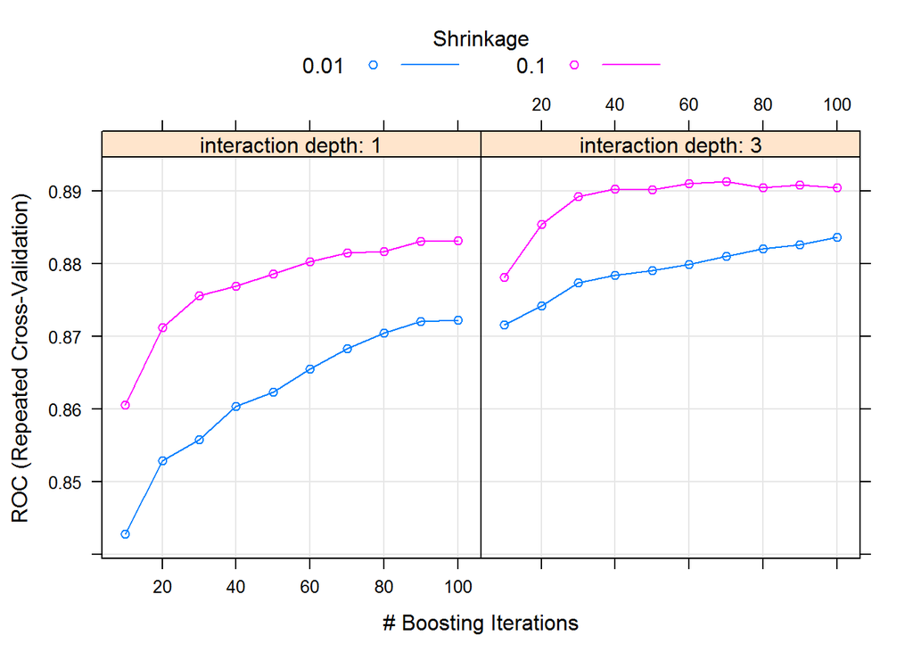

```r
plot(gbm.tune)          # Plot the performance of the training models
```

```r
res <- gbm.tune$results
names(res) <- c("depth","trees", "shrinkage","ROC", "Sens","Spec", "sdROC", "sdSens", "seSpec")
res
```

```
##    depth trees shrinkage ROC      Sens      Spec     sdROC     sdSens
## 1   0.01     1        20  10 0.8427841 1.0000000 0.0000000 0.03611838
## 21  0.10     1        20  10 0.8605086 0.8822788 0.6054354 0.03578934
## 11  0.01     3        20  10 0.8715774 1.0000000 0.0000000 0.03089030
## 31  0.10     3        20  10 0.8781108 0.8691875 0.6570420 0.03076454
## 2   0.01     1        20  20 0.8529213 1.0000000 0.0000000 0.03549078
## 22  0.10     1        20  20 0.8712473 0.8558029 0.6683934 0.03162742
## 12  0.01     3        20  20 0.8741703 1.0000000 0.0000000 0.03171584
## 32  0.10     3        20  20 0.8854194 0.8573558 0.7255105 0.02762690
## 3   0.01     1        20  30 0.8558085 1.0000000 0.0000000 0.03567276
## 23  0.10     1        20  30 0.8755714 0.8501971 0.6956456 0.02943791
## 13  0.01     3        20  30 0.8773493 1.0000000 0.0000000 0.03191512
## 33  0.10     3        20  30 0.8892648 0.8567548 0.7391291 0.02608782
## 4   0.01     1        20  40 0.8603948 1.0000000 0.0000000 0.03458529
## 24  0.10     1        20  40 0.8769587 0.8489519 0.7075976 0.02861556
```

[output cut: 67 more lines]

### GBM Model Predictions and Performance

Make predictions using the test data set

```r
testX <- testData[,4:61]
gbm.pred <- predict(gbm.tune,testX)
head(gbm.pred)
```

```
## [1] PS PS PS PS WS PS
## Levels: PS WS
```

Look at the confusion matrix

```r
confusionMatrix(gbm.pred,testData$Class)
```

```
## Confusion Matrix and Statistics
##
##           Reference
## Prediction  PS  WS
##         PS 570  88
##         WS  88 263
##
##                Accuracy : 0.8256
##                  95% CI : (0.8007, 0.8485)
##     No Information Rate : 0.6521
##     P-Value [Acc > NIR] : <2e-16
##
##                   Kappa : 0.6155
##  Mcnemar's Test P-Value : 1
##
##             Sensitivity : 0.8663
##             Specificity : 0.7493
##          Pos Pred Value : 0.8663
##          Neg Pred Value : 0.7493
##              Prevalence : 0.6521
##          Detection Rate : 0.5649
##    Detection Prevalence : 0.6521
##       Balanced Accuracy : 0.8078
##
##        'Positive' Class : PS
##
```

Draw the ROC curve

```r
gbm.probs <- predict(gbm.tune,testX,type="prob")
head(gbm.probs)
```

```
##          PS         WS
## 1 0.9519886 0.04801143
## 2 0.5958860 0.40411403
## 3 0.9727006 0.02729940
## 4 0.8006673 0.19933268
## 5 0.1125495 0.88745051
## 6 0.7896013 0.21039873
```

```r
gbm.ROC <- roc(predictor=gbm.probs$PS,
            response=testData$Class,
                levels=rev(levels(testData$Class)))
gbm.ROC
```

```
##
## Call:
## roc.default(response = testData$Class, predictor = gbm.probs$PS,     levels = rev(levels(testData$Class)))
##
## Data: gbm.probs$PS in 351 controls (testData$Class WS) < 658 cases (testData$Class PS).
## Area under the curve: 0.8972
```

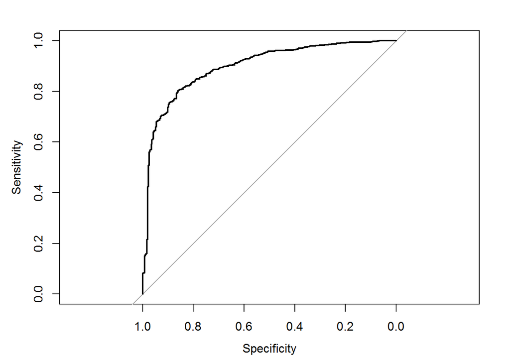

```
##
## Call:
## roc.default(response = testData$Class, predictor = gbm.probs$PS,     levels = rev(levels(testData$Class)))
##
## Data: gbm.probs$PS in 351 controls (testData$Class WS) < 658 cases (testData$Class PS).
## Area under the curve: 0.8972
```

```r
plot(gbm.ROC)
```

Plot the propability of poor segmentation

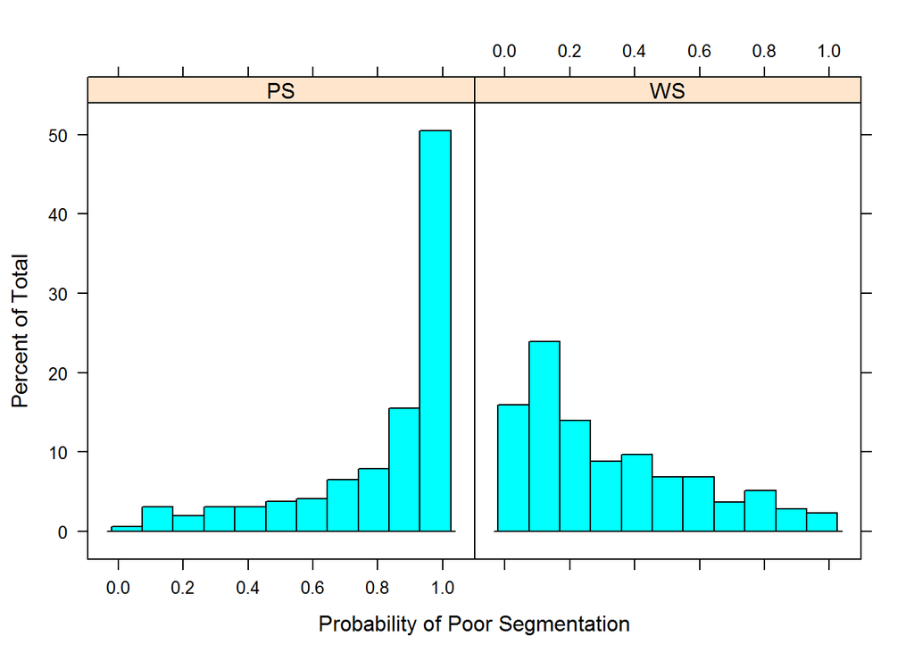

```r
histogram(~gbm.probs$PS|testData$Class,xlab="Probability of Poor Segmentation")
```

## SUPPORT VECTOR MACHINE MODEL

We follow steps similar to those above to build a SVM model

```r
# Set up for parallel procerssing
set.seed(1)
registerDoParallel(4,cores=4)
getDoParWorkers()
```

```
## [1] 4
```

Train and Tune the SVM

```r
system.time(
  svm.tune <- train(x=trainX,
                    y= trainData$Class,
                    method = "svmRadial",
                    tuneLength = 9,                 # 9 values of the cost function
                    preProc = c("center","scale"),
                    metric="ROC",
                    trControl=ctrl) # same as for gbm above
)
```

```
##    user  system elapsed
##    1.19    0.09   91.95
```

```r
svm.tune
```

```
## Support Vector Machines with Radial Basis Function Kernel
##
## 1010 samples
##   58 predictor
##    2 classes: 'PS', 'WS'
##
## Pre-processing: centered, scaled
## Resampling: Cross-Validated (10 fold, repeated 5 times)
## Summary of sample sizes: 909, 910, 908, 908, 909, 909, ...
## Resampling results across tuning parameters:
##
##   C      ROC        Sens       Spec       ROC SD      Sens SD
##    0.25  0.8753573  0.8610577  0.7096096  0.02927898  0.04005967
##    0.50  0.8813728  0.8638413  0.7150751  0.02829319  0.04262909
##    1.00  0.8843346  0.8691250  0.7248649  0.02694019  0.03891353
##    2.00  0.8840197  0.8716346  0.7210811  0.02574899  0.03671930
##    4.00  0.8790706  0.8716154  0.7157057  0.02546480  0.03755477
##    8.00  0.8702311  0.8688077  0.6988438  0.02571855  0.04189568
##   16.00  0.8637473  0.8731683  0.6870420  0.02692128  0.03865956
##   32.00  0.8536678  0.8734952  0.6717267  0.02765678  0.03807219
##   64.00  0.8479770  0.8747500  0.6587237  0.02803095  0.03953139
##   Spec SD
##   0.06790262
##   0.06726818
##   0.07195023
##   0.06904113
##   0.07440784
##   0.07439448
##   0.07292203
##   0.07457312
##   0.07521301
##
## Tuning parameter 'sigma' was held constant at a value of 0.01478354
## ROC was used to select the optimal model using  the largest value.
## The final values used for the model were sigma = 0.01478354 and C = 1.
```

Plot the SVM results

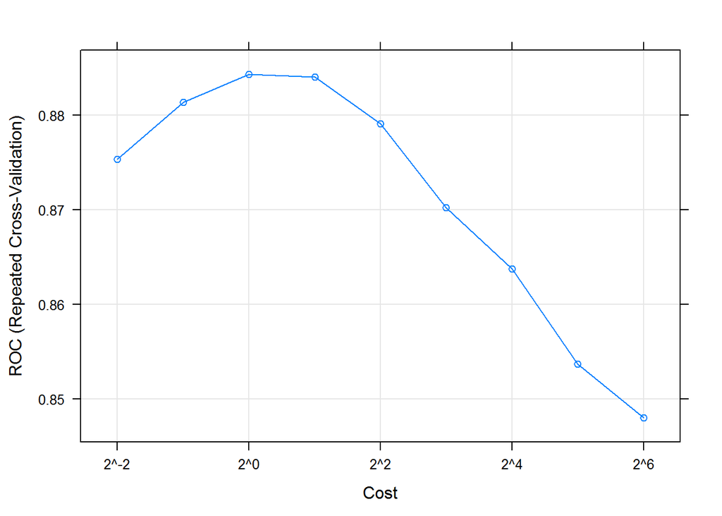

```r
plot(svm.tune,
     metric="ROC",
     scales=list(x=list(log=2)))
```

Make predictions on the test data with the SVM Model

```r
svm.pred <- predict(svm.tune,testX)
head(svm.pred)
```

```
## [1] PS WS PS WS WS PS
## Levels: PS WS
```

```r
confusionMatrix(svm.pred,testData$Class)
```

```
## Confusion Matrix and Statistics
##
##           Reference
## Prediction  PS  WS
##         PS 577  93
##         WS  81 258
##
##                Accuracy : 0.8276
##                  95% CI : (0.8028, 0.8504)
##     No Information Rate : 0.6521
##     P-Value [Acc > NIR] : <2e-16
##
##                   Kappa : 0.6169
##  Mcnemar's Test P-Value : 0.4043
##
##             Sensitivity : 0.8769
##             Specificity : 0.7350
##          Pos Pred Value : 0.8612
##          Neg Pred Value : 0.7611
##              Prevalence : 0.6521
##          Detection Rate : 0.5719
##    Detection Prevalence : 0.6640
##       Balanced Accuracy : 0.8060
##
##        'Positive' Class : PS
##
```

```r
svm.probs <- predict(svm.tune,testX,type="prob")
head(svm.probs)
```

```
##           PS         WS
## 1 0.87331353 0.12668647
## 2 0.08939323 0.91060677
## 3 0.96125603 0.03874397
## 4 0.47693994 0.52306006
## 5 0.02583604 0.97416396
## 6 0.68616379 0.31383621
```

```r
svm.ROC <- roc(predictor=svm.probs$PS,
               response=testData$Class,
               levels=rev(levels(testData$Class)))
svm.ROC
```

```
##
## Call:
## roc.default(response = testData$Class, predictor = svm.probs$PS,     levels = rev(levels(testData$Class)))
##
## Data: svm.probs$PS in 351 controls (testData$Class WS) < 658 cases (testData$Class PS).
## Area under the curve: 0.8918
```

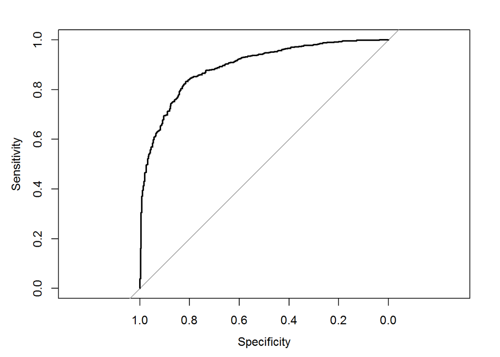

```
##
## Call:
## roc.default(response = testData$Class, predictor = svm.probs$PS,     levels = rev(levels(testData$Class)))
##
## Data: svm.probs$PS in 351 controls (testData$Class WS) < 658 cases (testData$Class PS).
## Area under the curve: 0.8918
```

```r
plot(svm.ROC)
```

## RANDOM FOREST MODEL

```r
set.seed(1)
rf.tune <-train(x=trainX,
                y= trainData$Class,
                method="rf",
                trControl= ctrl,
                prox=TRUE,allowParallel=TRUE)
rf.tune
```

```
## Random Forest
##
## 1010 samples
##   58 predictor
##    2 classes: 'PS', 'WS'
##
## No pre-processing
## Resampling: Cross-Validated (10 fold, repeated 5 times)
## Summary of sample sizes: 909, 910, 908, 908, 909, 909, ...
## Resampling results across tuning parameters:
##
##   mtry  ROC        Sens       Spec       ROC SD      Sens SD
##    2    0.8986558  0.8769567  0.7303604  0.02577346  0.03834408
##   30    0.8977217  0.8589038  0.7755105  0.02559927  0.03761580
##   58    0.8917536  0.8526490  0.7700601  0.02693856  0.03726022
##   Spec SD
##   0.07090950
##   0.06686930
##   0.06227585
##
## ROC was used to select the optimal model using  the largest value.
## The final value used for the model was mtry = 2.
```

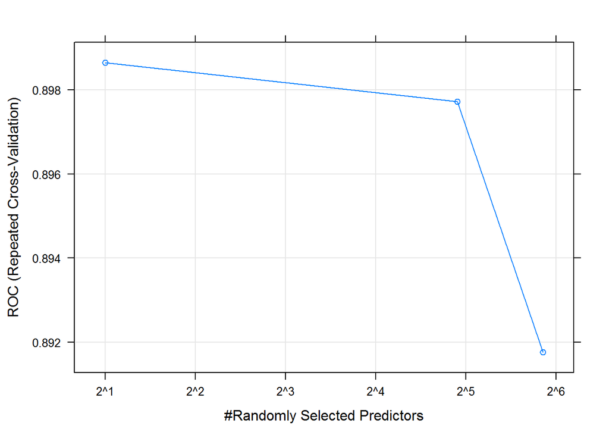

```r
# Plot the Random Forest results
plot(rf.tune,
     metric="ROC",
     scales=list(x=list(log=2)))
```

```r
# Random Forest Predictions
rf.pred <- predict(rf.tune,testX)
head(rf.pred)
```

```
## [1] PS PS PS PS WS PS
## Levels: PS WS
```

```r
confusionMatrix(rf.pred,testData$Class)
```

```
## Confusion Matrix and Statistics
##
##           Reference
## Prediction  PS  WS
##         PS 575  98
##         WS  83 253
##
##                Accuracy : 0.8206
##                  95% CI : (0.7955, 0.8438)
##     No Information Rate : 0.6521
##     P-Value [Acc > NIR] : <2e-16
##
##                   Kappa : 0.6006
##  Mcnemar's Test P-Value : 0.2981
##
##             Sensitivity : 0.8739
##             Specificity : 0.7208
##          Pos Pred Value : 0.8544
##          Neg Pred Value : 0.7530
##              Prevalence : 0.6521
##          Detection Rate : 0.5699
##    Detection Prevalence : 0.6670
##       Balanced Accuracy : 0.7973
##
##        'Positive' Class : PS
##
```

```r
rf.probs <- predict(rf.tune,testX,type="prob")
head(rf.probs)
```

```
##       PS    WS
## 1  0.900 0.100
## 3  0.504 0.496
## 8  0.946 0.054
## 9  0.576 0.424
## 11 0.244 0.756
## 12 0.752 0.248
```

```r
rf.ROC <- roc(predictor=rf.probs$PS,
               response=testData$Class,
               levels=rev(levels(testData$Class)))
rf.ROC
```

```
##
## Call:
## roc.default(response = testData$Class, predictor = rf.probs$PS,     levels = rev(levels(testData$Class)))
##
## Data: rf.probs$PS in 351 controls (testData$Class WS) < 658 cases (testData$Class PS).
## Area under the curve: 0.8962
```

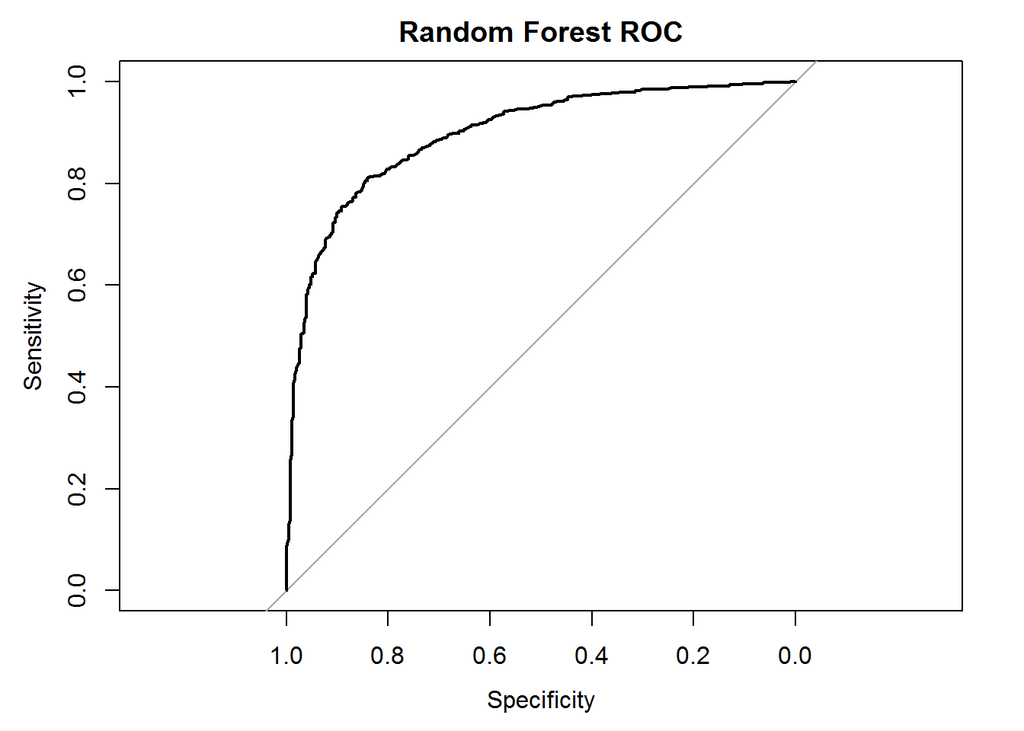

```
##
## Call:
## roc.default(response = testData$Class, predictor = rf.probs$PS,     levels = rev(levels(testData$Class)))
##
## Data: rf.probs$PS in 351 controls (testData$Class WS) < 658 cases (testData$Class PS).
## Area under the curve: 0.8962
```

```r
plot(rf.ROC,main = "Random Forest ROC")
```

## Comparing Multiple Models

Having set the seed to 1 before running gbm.tune, svm.tune and rf.tune we have generated paired samples (See Hothorn at al, “The design and analysis of benchmark experiments-Journal of Computational and Graphical Statistics (2005) vol 14 (3) pp 675-699) and are in a position to compare models using a resampling technique.

```r
rValues <- resamples(list(svm=svm.tune,gbm=gbm.tune,rf=rf.tune))
rValues$values
```

```
##       Resample   svm~ROC  svm~Sens  svm~Spec   gbm~ROC  gbm~Sens  gbm~Spec
## 1  Fold01.Rep1 0.8640203 0.8750000 0.7027027 0.9011824 0.8750000 0.8108108
## 2  Fold01.Rep2 0.9034188 0.9384615 0.7777778 0.8782051 0.9076923 0.5833333
## 3  Fold01.Rep3 0.8703547 0.8750000 0.6756757 0.8690878 0.8593750 0.6486486
## 4  Fold01.Rep4 0.8458615 0.8281250 0.7027027 0.8669764 0.8906250 0.6756757
## 5  Fold01.Rep5 0.8847128 0.9218750 0.6756757 0.9075169 0.9375000 0.7297297
## 6  Fold02.Rep1 0.8793403 0.8437500 0.8055556 0.8862847 0.7812500 0.8611111
## 7  Fold02.Rep2 0.8255912 0.8125000 0.7027027 0.8374155 0.7656250 0.7027027
## 8  Fold02.Rep3 0.9322245 0.8923077 0.8378378 0.9355509 0.8769231 0.8648649
## 9  Fold02.Rep4 0.8623311 0.8750000 0.7567568 0.8572635 0.8593750 0.7567568
## 10 Fold02.Rep5 0.8999155 0.9062500 0.6756757 0.8893581 0.8593750 0.7027027
## 11 Fold03.Rep1 0.8939709 0.8769231 0.8108108 0.8923077 0.8461538 0.7567568
## 12 Fold03.Rep2 0.9020270 0.9062500 0.7027027 0.9045608 0.9218750 0.7837838
## 13 Fold03.Rep3 0.8741554 0.8437500 0.6216216 0.8758446 0.8906250 0.6756757
## 14 Fold03.Rep4 0.8836806 0.8750000 0.7500000 0.8862847 0.8593750 0.7500000
```

[output cut: 87 more lines]

```r
summary(rValues)
```

```
##
## Call:
## summary.resamples(object = rValues)
##
## Models: svm, gbm, rf
## Number of resamples: 50
##
## ROC
##       Min. 1st Qu. Median   Mean 3rd Qu.   Max. NA's
## svm 0.8103  0.8706 0.8845 0.8843  0.9026 0.9379    0
## gbm 0.8374  0.8751 0.8894 0.8913  0.9082 0.9557    0
## rf  0.8467  0.8823 0.8969 0.8987  0.9160 0.9624    0
##
## Sens
##       Min. 1st Qu. Median   Mean 3rd Qu.   Max. NA's
## svm 0.7812  0.8438 0.8750 0.8691  0.8906 0.9385    0
## gbm 0.7656  0.8308 0.8594 0.8577  0.8769 0.9375    0
## rf  0.7812  0.8462 0.8750 0.8770  0.9062 0.9531    0
##
## Spec
##       Min. 1st Qu. Median   Mean 3rd Qu.   Max. NA's
## svm 0.5556  0.6757 0.7297 0.7249  0.7725 0.8649    0
## gbm 0.5833  0.7027 0.7568 0.7456  0.7838 0.8649    0
## rf  0.5676  0.6757 0.7297 0.7304  0.7838 0.8649    0
```

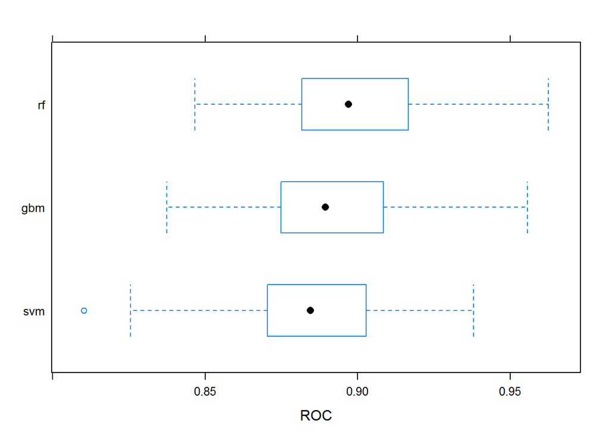

```r
bwplot(rValues,metric="ROC")            # boxplot
```

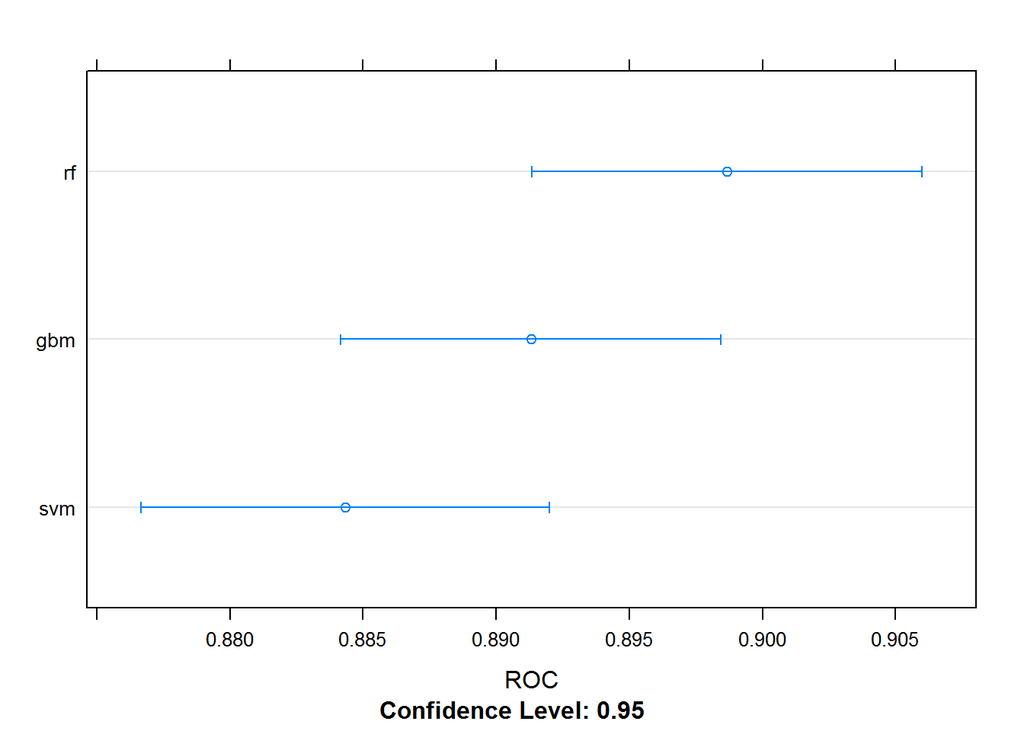

```r
dotplot(rValues,metric="ROC")           # dotplot
```

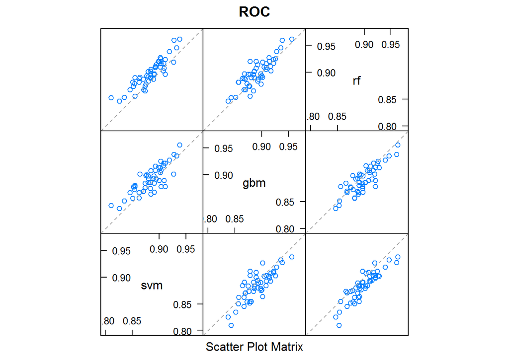

```r
splom(rValues,metric="ROC")
```